# Regression and Variable Selection

The objective of this case is to get you started with regression model building, variable selection, and model evaluation in R. We use Boston Housing dataset as the example for demonstration. Code in this file is not the only correct way to do things, however it is important for you to understand what each statement does. Mostly, only the basic commands are introduced, but you are recommended to explore and study yourself.

## Preparing

### Load Data

```r
library(MASS)
data(Boston); #this data is in MASS package
dim(Boston)
```

```
## [1] 506  14
```

```r
names(Boston)
```

```
##  [1] "crim"    "zn"      "indus"   "chas"    "nox"     "rm"      "age"
##  [8] "dis"     "rad"     "tax"     "ptratio" "black"   "lstat"   "medv"
```

Since this dataset is in package `MASS`, you can find the variable description in the help document:

```r
?Boston
```

We skip the Exploratory Data Analysis (EDA) in this notes, but you should not omit it in your HW and Cases. EDA is very important and always the first analysis to do before any modeling.

### Splitting data to training and testing samples

Next we sample 90% of the original data and use it as the training set. The remaining 10% is used as test set. The regression model will be built on the training set and future performance of your model will be evaluated with the test set.

```r
index = sample(nrow(Boston),nrow(Boston)*0.90)
Boston.train = Boston[index,]
Boston.test = Boston[-index,]
```

### (Optional) Standardization

If we want our results to be invariant to the units and the parameter estimates $\beta_i$ to be comparible, we can standardize the variables. Essentially we are replacing the original values with their z-score.

1st Way: create new variables manually.

```r
Boston$sd.crim = (Boston$crim-mean(Boston$crim))/sd(Boston$crim);
```

2nd Way: Use `scale()` function.

```r
Boston$sd.crim = scale(Boston$crim);
```

Usually, if necessary, you may want to standardize all covariates (explanatory variabls)

```r
Boston[,-14]<- scale(Boston[,-14])
```

The technique is not as important in linear regression because it will only affect the interpretation but not the model estimation and inference.

## Model Building

### Simple linear regression

We first fit a simple linear regression using, say “lstat”, as $X$.

```r
# draw a scatter plot
plot(medv~lstat, data=Boston.train)
# fit the simple linear regression
model0<- lm(medv~lstat, data = Boston.train)
model0
```

```
##
## Call:
## lm(formula = medv ~ lstat, data = Boston.train)
##
## Coefficients:
## (Intercept)        lstat
##     34.5269      -0.9553
```

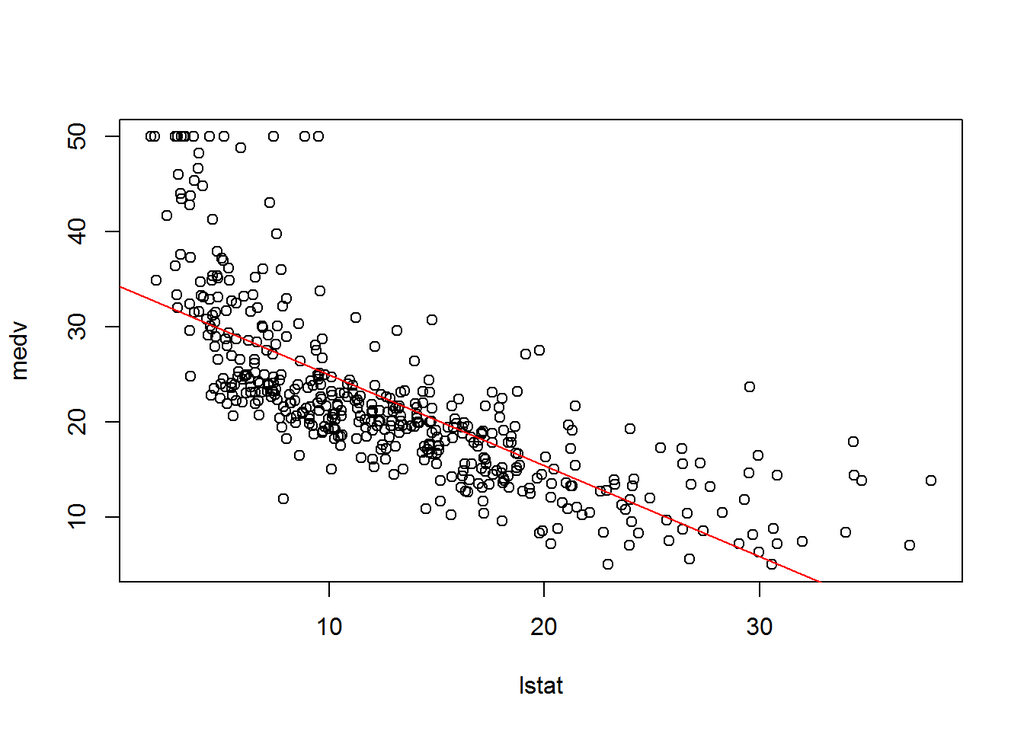

```r
abline(model0, col="red")
```

To get more detailed outputs of the fitted model, we use function `summary()`.

```r
sum.model0<- summary(model0)
sum.model0
```

```
##
## Call:
## lm(formula = medv ~ lstat, data = Boston.train)
##
## Residuals:
##     Min      1Q  Median      3Q     Max
## -15.099  -3.926  -1.413   1.949  24.577
##
## Coefficients:
##             Estimate Std. Error t value Pr(>|t|)
## (Intercept) 34.52693    0.59707   57.83   <2e-16 ***
## lstat       -0.95531    0.04083  -23.40   <2e-16 ***
## ---
## Signif. codes:  0 '***' 0.001 '**' 0.01 '*' 0.05 '.' 0.1 ' ' 1
##
## Residual standard error: 6.239 on 453 degrees of freedom
## Multiple R-squared:  0.5472, Adjusted R-squared:  0.5462
## F-statistic: 547.4 on 1 and 453 DF,  p-value: < 2.2e-16
```

Note that both the objects “model1” and “sum.model1” are lists of components.

```r
names(model0)
```

```
##  [1] "coefficients"  "residuals"     "effects"       "rank"
##  [5] "fitted.values" "assign"        "qr"            "df.residual"
##  [9] "xlevels"       "call"          "terms"         "model"
```

```r
names(sum.model0)
```

```
##  [1] "call"          "terms"         "residuals"     "coefficients"
##  [5] "aliased"       "sigma"         "df"            "r.squared"
##  [9] "adj.r.squared" "fstatistic"    "cov.unscaled"
```

You may get the confidence interval for the estimated coefficients. Recall the formula to calculate the confidence interval: $\hat{\beta}_j \pm t_{\alpha/2, n-p-1}\times SE(\hat{\beta}_j)$.

```r
confint(model0)
```

```
##                 2.5 %     97.5 %
## (Intercept) 33.353546 35.7003063
## lstat       -1.035553 -0.8750652
```

To predict “medv” given new set of covariates, we use function `predict()`.

```r
pred.model0<- predict(model0, newdata = Boston.test)
```

Be careful that the argument “newdata” has to be a dataframe. You can always convert a table, vector or matrix to a dataframe using `data.frame()`.

```r
predict(model0, newdata = data.frame(lstat=c(5,10,15)), interval = "confidence")
```

```
##        fit      lwr      upr
## 1 29.75038 28.90365 30.59711
## 2 24.97383 24.35817 25.58949
## 3 20.19729 19.59473 20.79985
```

### Multiple linear regreesion

The following model includes all $x$ varables in the model

```r
model1<- lm(medv~crim+zn+indus+chas+nox+rm+age+dis+rad+tax+ptratio+black+lstat, data=Boston.train)
# more convenient way
model1<- lm(medv~., data=Boston.train)
# summary
summary(model1)
```

```
##
## Call:
## lm(formula = medv ~ ., data = Boston.train)
##
## Residuals:
##      Min       1Q   Median       3Q      Max
## -15.4563  -2.7654  -0.6129   1.6890  25.4007
##
## Coefficients:
##               Estimate Std. Error t value Pr(>|t|)
## (Intercept)  38.643113   5.524674   6.995 9.92e-12 ***
## crim         -0.107707   0.033975  -3.170  0.00163 **
## zn            0.047572   0.014949   3.182  0.00156 **
## indus         0.041035   0.067033   0.612  0.54075
## chas          2.911829   0.929830   3.132  0.00185 **
## nox         -19.100280   4.096793  -4.662 4.15e-06 ***
## rm            3.574585   0.455649   7.845 3.30e-14 ***
## age           0.005920   0.014062   0.421  0.67394
## dis          -1.479887   0.219422  -6.744 4.83e-11 ***
## rad           0.322629   0.071326   4.523 7.84e-06 ***
## tax          -0.013197   0.004070  -3.243  0.00127 **
## ptratio      -0.946273   0.141438  -6.690 6.77e-11 ***
## black         0.009004   0.002795   3.221  0.00137 **
## lstat        -0.556068   0.053690 -10.357  < 2e-16 ***
## ---
## Signif. codes:  0 '***' 0.001 '**' 0.01 '*' 0.05 '.' 0.1 ' ' 1
##
## Residual standard error: 4.855 on 441 degrees of freedom
## Multiple R-squared:  0.7331, Adjusted R-squared:  0.7252
## F-statistic: 93.16 on 13 and 441 DF,  p-value: < 2.2e-16
```

Are there any insignificant variables?

```r
model2<- lm(medv~. -indus -age, data=Boston.train)
summary(model2)
```

```
##
## Call:
## lm(formula = medv ~ . - indus - age, data = Boston.train)
##
## Residuals:
##      Min       1Q   Median       3Q      Max
## -15.5385  -2.7500  -0.5452   1.6145  25.6466
##
## Coefficients:
##               Estimate Std. Error t value Pr(>|t|)
## (Intercept)  38.224527   5.481116   6.974 1.13e-11 ***
## crim         -0.108520   0.033895  -3.202 0.001465 **
## zn            0.045930   0.014755   3.113 0.001974 **
## chas          2.987542   0.922068   3.240 0.001285 **
## nox         -17.970184   3.777086  -4.758 2.65e-06 ***
## rm            3.590932   0.443660   8.094 5.62e-15 ***
## dis          -1.535233   0.204605  -7.503 3.44e-13 ***
## rad           0.307140   0.067658   4.540 7.27e-06 ***
## tax          -0.012017   0.003616  -3.324 0.000962 ***
## ptratio      -0.929866   0.139449  -6.668 7.73e-11 ***
## black         0.009032   0.002784   3.244 0.001267 **
## lstat        -0.545371   0.050023 -10.902  < 2e-16 ***
## ---
## Signif. codes:  0 '***' 0.001 '**' 0.01 '*' 0.05 '.' 0.1 ' ' 1
##
## Residual standard error: 4.847 on 443 degrees of freedom
## Multiple R-squared:  0.7327, Adjusted R-squared:  0.7261
## F-statistic: 110.4 on 11 and 443 DF,  p-value: < 2.2e-16
```

**Exercise**: get the predicted value of these two models, and calculate mean squared prediction error (MSPE)

```r
pred.model1<-
pred.model2<-
mspe.model1<-
mspe.model2<-
```

## Model diagnostics

The aim of model diagnostics is to check if the model assumptions are valid. Recall that residual plot is primary tool for model diagnostics.

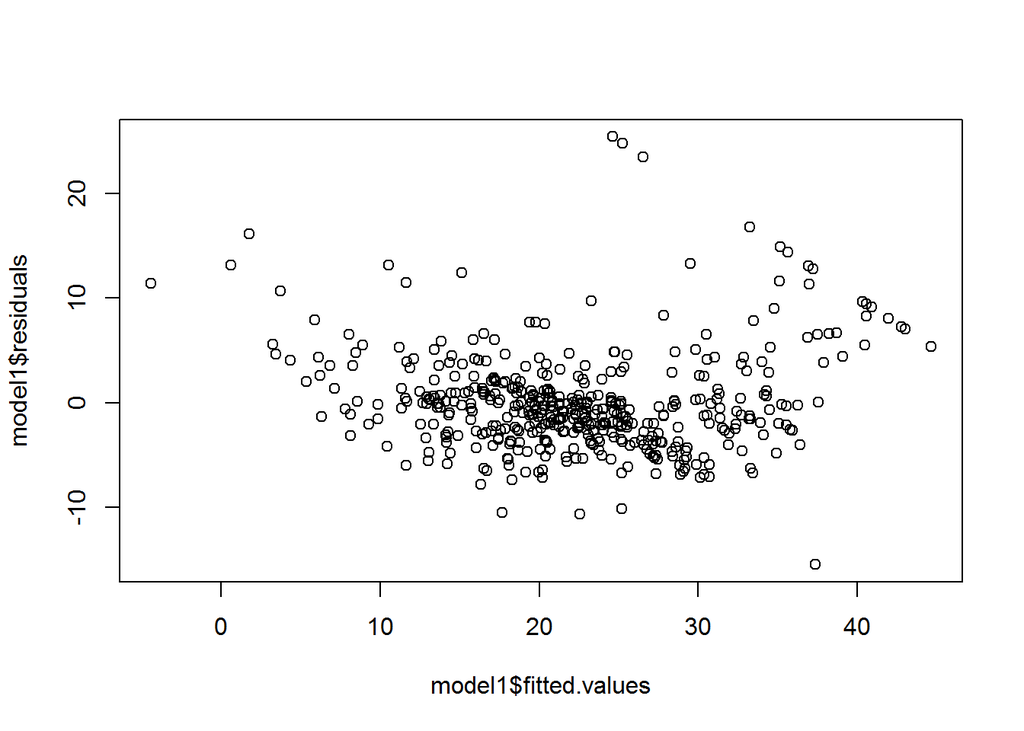

```r
plot(model1$fitted.values, model1$residuals)
```

What can you see from this plot?

More plots for model diagnostics.

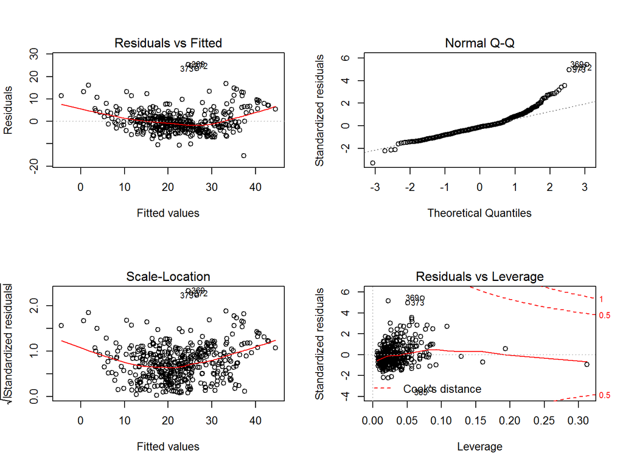

```r
#par(mar=c(4,4.5,2,1), oma=c(2,1,1,2))
par(mfrow=c(2,2)) # to specify the figure layout
plot(model1)
```

**HW bonus problem**: try to address the quadratic issue. (Hint: find possible variables that may have quadratic relationship to the response, and build new model.) Note that you need to include this new model as a candidate model and do the model comparison.

## Model evaluation

Suppose that everything in model diagnostics is okay. In other words, the model we have built is fairly a valid model. Then we need to evaluate the model performance in terms of different metrics.

Commonly used metrics include **MSE, (adjusted) $R^2$, AIC, BIC** for in-sample performance, and **MSPE** for out-of-sample performance.

### In-sample performance

```r
sum.model1<- summary(model1)
# MSE
(sum.model1$sigma)^2
```

```
## [1] 23.57052
```

$R^2$ of the model

```r
sum.model1$r.squared
```

```
## [1] 0.7330735
```

```r
sum.model1$adj.r.squared
```

```
## [1] 0.7252049
```

AIC and BIC of the model, these are information criteria. Smaller values indicate better fit.

```r
AIC(model1)
```

```
## [1] 2744.813
```

```r
BIC(model1)
```

```
## [1] 2806.617
```

BIC, AIC, and Adjusted $R^2$ have complexity penalty in the definition, thus when comparing across different models they are better indicators on how well the model will perform on future data.

### Out-of-sample prediction (test error)

#### For a single testing sample:

Recall the exercise problem…

```r
pred.model1<-
pred.model2<-
mpse.model1<-
mpse.model2<-
```

#### Cross-validation

Instead of fitting a model on a pre-specified 90% training sample and evaluate the MSPE on the hold-out 10% testing sample, it is more reliable to use cross-validation for out-of-sample performance evaluation. For k-fold cross-validation, the dataset is divided into k parts (equal sample size). Each part serves as the testing sample in and the rest (k-1 together) serves as training sample. This training/testing procedure is iteratively performed k times. The CV score is usually the average of the metric of out-of-sample performance across k iterations.

Note

1. We use the **entire** dataset for cross validation
2. We need to use glm instead of lm to fit the model (if we want to use cv.glm function in boot package)
3. The default measure of performance is the Mean Squared Error (MSE). If we want to use another measure we need to define a cost function.

10-fold Cross Validation

```r
library(boot)
model.glm1 = glm(medv~., data = Boston)
cv.glm(data = Boston, glmfit = model.glm1, K = 10)$delta[2]
```

```
## [1] 23.44035
```

Comparing with model 2

```r
model.glm2 = glm(medv~. -indus -age, data = Boston)
cv.glm(data = Boston, glmfit = model.glm2, K = 10)$delta[2]
```

```
## [1] 23.79542
```

LOOCV (Leave-one-out Cross Validation)

```r
cv.glm(data = Boston, glmfit = model.glm1, K = nrow(Boston))$delta[2]
```

Now we define a MAD cost function as the CV score. The function takes 2 input vectors, pi = predicted values, r = actual values.

```r
MAD_cost = function(pi, r){
  return(mean(abs(pi-r)))
}
cv.glm(data = Boston, glmfit = model.glm1, cost = MAD_cost, K = 10)$delta[2]
```

```
## [1] 3.406177
```

**Exercise (HW)**: Do 10-fold cross-validation for all candidate models, and compare the CV score in terms of MSE and MAE.

## Variable Selection

### Compare Model Fit Manually

```r
model0
model1
model2

AIC(model0); BIC(model0)
AIC(model1); BIC(model1)
AIC(model2); BIC(model2)
```

**Exercise**: Compare MSE, $R^2$, and MSPE of these three models.

### Best Subset Regression

The ‘leaps’ package provides procedures for best subset regression.

```r
install.packages('leaps')
```

```r
library(leaps)
```

Which subset of variables should you include in order to minimize BIC?

```r
#regsubsets only takes data frame as input
model.subset<- regsubsets(medv~.,data=Boston.train, nbest=2, nvmax = 10)
summary(model.subset)
```

```
## Subset selection object
## Call: regsubsets.formula(medv ~ ., data = Boston.train, nbest = 2,
##     nvmax = 10)
## 13 Variables  (and intercept)
##         Forced in Forced out
## crim        FALSE      FALSE
## zn          FALSE      FALSE
## indus       FALSE      FALSE
## chas        FALSE      FALSE
## nox         FALSE      FALSE
## rm          FALSE      FALSE
## age         FALSE      FALSE
## dis         FALSE      FALSE
## rad         FALSE      FALSE
## tax         FALSE      FALSE
## ptratio     FALSE      FALSE
## black       FALSE      FALSE
## lstat       FALSE      FALSE
## 2 subsets of each size up to 10
## Selection Algorithm: exhaustive
##           crim zn  indus chas nox rm  age dis rad tax ptratio black lstat
## 1  ( 1 )  " "  " " " "   " "  " " " " " " " " " " " " " "     " "   "*"
## 1  ( 2 )  " "  " " " "   " "  " " "*" " " " " " " " " " "     " "   " "
## 2  ( 1 )  " "  " " " "   " "  " " "*" " " " " " " " " " "     " "   "*"
## 2  ( 2 )  " "  " " " "   " "  " " " " " " " " " " " " "*"     " "   "*"
## 3  ( 1 )  " "  " " " "   " "  " " "*" " " " " " " " " "*"     " "   "*"
## 3  ( 2 )  " "  " " " "   "*"  " " "*" " " " " " " " " " "     " "   "*"
## 4  ( 1 )  " "  " " " "   " "  " " "*" " " "*" " " " " "*"     " "   "*"
## 4  ( 2 )  " "  " " " "   "*"  " " "*" " " " " " " " " "*"     " "   "*"
## 5  ( 1 )  " "  " " " "   " "  "*" "*" " " "*" " " " " "*"     " "   "*"
## 5  ( 2 )  " "  " " " "   " "  " " "*" " " "*" " " " " "*"     "*"   "*"
## 6  ( 1 )  " "  " " " "   "*"  "*" "*" " " "*" " " " " "*"     " "   "*"
## 6  ( 2 )  " "  " " " "   " "  "*" "*" " " "*" " " " " "*"     "*"   "*"
## 7  ( 1 )  " "  " " " "   "*"  "*" "*" " " "*" " " " " "*"     "*"   "*"
## 7  ( 2 )  " "  "*" " "   "*"  "*" "*" " " "*" " " " " "*"     " "   "*"
## 8  ( 1 )  " "  "*" " "   "*"  "*" "*" " " "*" " " " " "*"     "*"   "*"
## 8  ( 2 )  " "  " " " "   "*"  "*" "*" " " "*" "*" " " "*"     "*"   "*"
## 9  ( 1 )  "*"  " " " "   "*"  "*" "*" " " "*" "*" " " "*"     "*"   "*"
## 9  ( 2 )  " "  " " " "   "*"  "*" "*" " " "*" "*" "*" "*"     "*"   "*"
## 10  ( 1 ) "*"  " " " "   "*"  "*" "*" " " "*" "*" "*" "*"     "*"   "*"
## 10  ( 2 ) " "  "*" " "   "*"  "*" "*" " " "*" "*" "*" "*"     "*"   "*"
```

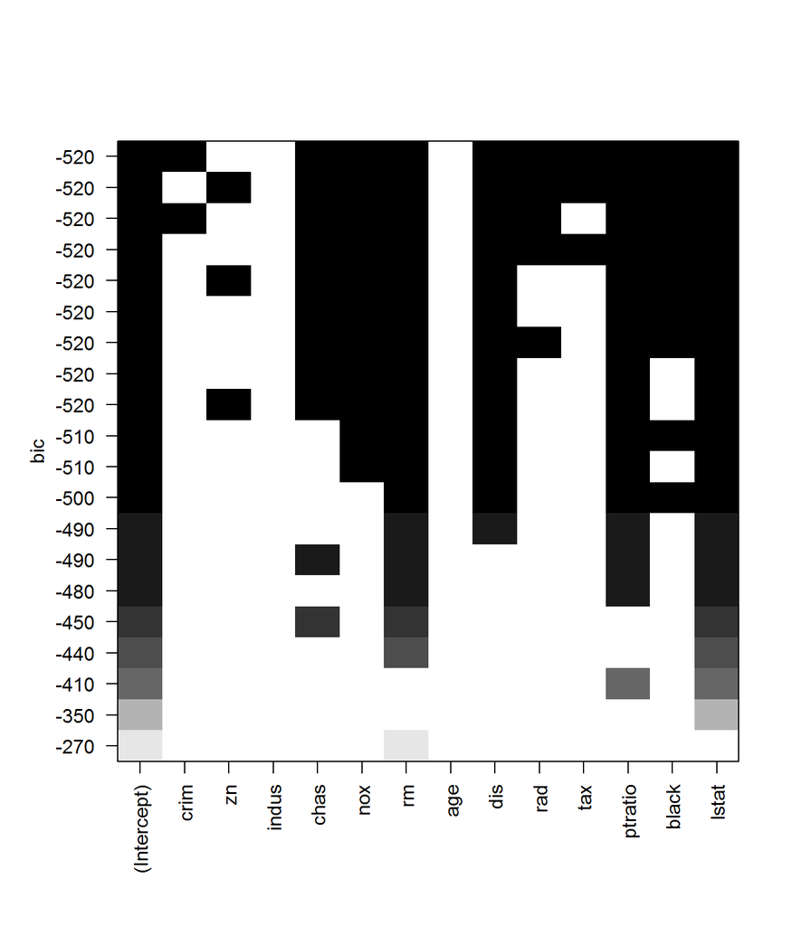

```r
par(mfrow=c(1,1))
plot(model.subset, scale="bic")
```

Each row represents a model. Black indicates that a variable is included in the model, while white indicates that it is not. The argument scale = “Cp”, “adjr2”, “r2” or “bic”.

### Forward/Backward/Stepwise Regression Using AIC

To perform the Forward/Backward/Stepwise Regression in R, we need to define the starting points:

```r
nullmodel<- lm(medv~1, data=Boston.train)
fullmodel<- lm(medv~., data=Boston.train)
```

nullmodel is the model with no varaible in it, while fullmodel is the model with every variable in it.

#### Backward Elimination

```r
model.step.b<- step(fullmodel,direction='backward')
```

```
## Start:  AIC=1451.58
## medv ~ crim + zn + indus + chas + nox + rm + age + dis + rad +
##     tax + ptratio + black + lstat
##
##           Df Sum of Sq   RSS    AIC
## - age      1      4.18 10399 1449.8
## - indus    1      8.83 10403 1450.0
## <none>                 10395 1451.6
## - chas     1    231.15 10626 1459.6
## - crim     1    236.88 10632 1459.8
## - zn       1    238.70 10633 1459.9
## - black    1    244.54 10639 1460.2
## - tax      1    247.83 10642 1460.3
## - rad      1    482.26 10877 1470.2
## - nox      1    512.34 10907 1471.5
## - ptratio  1   1055.05 11450 1493.6
## - dis      1   1072.18 11467 1494.2
## - rm       1   1450.64 11845 1509.0
## - lstat    1   2528.38 12923 1548.6
##
## Step:  AIC=1449.76
## medv ~ crim + zn + indus + chas + nox + rm + dis + rad + tax +
##     ptratio + black + lstat
##
##           Df Sum of Sq   RSS    AIC
## - indus    1      8.70 10408 1448.1
## <none>                 10399 1449.8
## - chas     1    233.51 10632 1457.9
## - zn       1    234.75 10634 1457.9
## - crim     1    236.97 10636 1458.0
## - tax      1    246.03 10645 1458.4
## - black    1    249.65 10648 1458.6
## - rad      1    478.15 10877 1468.2
## - nox      1    529.46 10928 1470.4
## - ptratio  1   1051.24 11450 1491.6
## - dis      1   1205.54 11604 1497.7
## - rm       1   1547.61 11946 1510.9
## - lstat    1   2797.44 13196 1556.2
##
## Step:  AIC=1448.14
## medv ~ crim + zn + chas + nox + rm + dis + rad + tax + ptratio +
##     black + lstat
##
##           Df Sum of Sq   RSS    AIC
## <none>                 10408 1448.1
## - zn       1    227.63 10635 1456.0
## - crim     1    240.83 10648 1456.5
## - chas     1    246.63 10654 1456.8
## - black    1    247.25 10655 1456.8
## - tax      1    259.51 10667 1457.3
## - rad      1    484.14 10892 1466.8
## - nox      1    531.78 10939 1468.8
## - ptratio  1   1044.60 11452 1489.7
## - dis      1   1322.69 11730 1500.6
## - rm       1   1539.06 11946 1508.9
## - lstat    1   2792.45 13200 1554.3
```

#### Forward Selection

```r
model.step.f<- step(nullmodel, scope=list(lower=nullmodel, upper=fullmodel), direction='forward')
```

#### Stepwise Selection (Output Omitted)

```r
model.step.s<- step(nullmodel, scope=list(lower=nullmodel, upper=fullmodel), direction='both')
```

**Exercise (HW)**: 1. Comparing in-sample and out-of-sample performance between these reduced models. 2. Conduct 10-fold cross validation on the full sample and compare the CV scores.

- For pros and cons of variable/model selection using the common fit statistics: (adjusted) $R^2$, MSE, AIC, BIC, etc. refer to Ch9 in “Applied Linear Regression Models” by Kutner et al.
- For other variable selection methods refer to section 3.4 - 3.8 of [“Elements of Statistical Learning” (Free Online)](http://www-stat.stanford.edu/~tibs/ElemStatLearn/).

## Some tips for HW2 (Case2)

The goal of this case study is to build linear regression models, interpret the outputs, and compare different candidate models in terms of different metrics. It is also important to conduct model diagnostics and check if the model assumptions are valid.

The case report may include:

- Introduction (Describe problem and data)
- EDA
- Modeling (Describe each of the candidate models, and state the motivations and pros/cons of each models.)
- Comprehensive model comparison (make a professional table)